# Codveda Data Science Internship

## Level 2 (intermediate), Task 2 – Machine Learning

### Logistic Regression Classification using the Iris Dataset

**Intern:** Nku George Ekong  
**Domain:** Data Science

### Task Overview

Machine learning classification models are widely used to predict categorical outcomes based on input features. In this Task, a logistic regression classifier is developed to predict the species of iris flowers based on their physical characteristics. The dataset used for this analysis is the Iris dataset, which contains measurements of sepal and petal dimensions for three species of iris flowers (Setosa, Versicolor, and Virginica). The analysis will involve preprocessing the dataset, training a classification model, evaluating its performance using statistical metrics, and comparing the model with other machine learning algorithms, such as the Random Forest and the Support Vector Machine (SVM). The ultimate goal of this task is to determine how accurately machine learning models can classify iris species based on their measurements.

```python
##Import Required Libraries
import pandas as pd
import numpy as np

import matplotlib.pyplot as plt
import seaborn as sns

from sklearn.preprocessing import LabelEncoder
from sklearn.preprocessing import StandardScaler

from sklearn.model_selection import train_test_split

from sklearn.linear_model import LogisticRegression
from sklearn.ensemble import RandomForestClassifier
from sklearn.svm import SVC

from sklearn.metrics import accuracy_score
from sklearn.metrics import precision_score
from sklearn.metrics import recall_score
from sklearn.metrics import confusion_matrix
from sklearn. metrics import classification_report
from sklearn.metrics import roc_curve
from sklearn.metrics import auc
```

```python
#Load the Dataset
iris = pd.read_csv(r"C:\Users\HomePC\OneDrive\Desktop\Notebook files\Iris_Dataset.csv")

iris.head()
```

|  | sepal_length | sepal_width | petal_length | petal_width | species |
| --- | --- | --- | --- | --- | --- |
| 0 | 5.1 | 3.5 | 1.4 | 0.2 | setosa |
| 1 | 4.9 | 3.0 | 1.4 | 0.2 | setosa |
| 2 | 4.7 | 3.2 | 1.3 | 0.2 | setosa |
| 3 | 4.6 | 3.1 | 1.5 | 0.2 | setosa |
| 4 | 5.0 | 3.6 | 1.4 | 0.2 | setosa |

## Dataset Structure and Inspection

Understanding the structure of the dataset is an important preliminary step in machine learning. This step involves examining the number of observations, variable names, and data types. Inspecting the dataset helps confirm that numerical and categorical variables are properly recognized and ensures that the dataset is ready for preprocessing.

```python
iris.shape
```

```
(150, 5)
```

```python
iris.info()
```

```
<class 'pandas.core.frame.DataFrame'>
RangeIndex: 150 entries, 0 to 149
Data columns (total 5 columns):
 #   Column        Non-Null Count  Dtype
---  ------        --------------  -----
 0   sepal_length  150 non-null    float64
 1   sepal_width   150 non-null    float64
 2   petal_length  150 non-null    float64
 3   petal_width   150 non-null    float64
 4   species       150 non-null    object
dtypes: float64(4), object(1)
memory usage: 6.0+ KB
```

```python
iris.columns
```

```
Index(['sepal_length', 'sepal_width', 'petal_length', 'petal_width',
       'species'],
      dtype='object')
```

```python
#checking for empty rows
iris.isnull().sum()
```

```
sepal_length    0
sepal_width     0
petal_length    0
petal_width     0
species         0
dtype: int64
```

The data set is devoid of missing rows or values.

# Encode the Target Variable

Machine learning algorithms require numerical input. Since the species variable is categorical, it has to be converted into a numerical variable. Label encoding is used to assign numeric values to each species category. This transformation allows the classification model to interpret the species variable during training.

```python
encoded_val = LabelEncoder()

iris["species_encoded"] = encoded_val.fit_transform(iris["species"])

iris.head()
```

|  | sepal_length | sepal_width | petal_length | petal_width | species | species_encoded |
| --- | --- | --- | --- | --- | --- | --- |
| 0 | 5.1 | 3.5 | 1.4 | 0.2 | setosa | 0 |
| 1 | 4.9 | 3.0 | 1.4 | 0.2 | setosa | 0 |
| 2 | 4.7 | 3.2 | 1.3 | 0.2 | setosa | 0 |
| 3 | 4.6 | 3.1 | 1.5 | 0.2 | setosa | 0 |
| 4 | 5.0 | 3.6 | 1.4 | 0.2 | setosa | 0 |

## Features Selection and Target Definition

To train a machine learning model, the dataset must be divided into: **Predictor variables (features)** These are the independent variables used to make predictions **Target variable** This is the dependent variable that the model aims to predict In this analysis, the flower measurements serve as the predictor variables, while the encoded species column represents the target variable.

```python
X = iris[['sepal_length','sepal_width','petal_length','petal_width']]

y = iris['species_encoded']
```

## Feature Scaling

Machine learning models perform more efficiently when numerical variables are scaled to a similar range. Feature scaling ensures that variables with larger magnitudes do not dominate the model training process. Standardization is applied using the StandardScaler method, which transforms the data so that it has a mean of zero and a standard deviation of one.

```python
scaled_var = StandardScaler()

X_scaled = scaled_var.fit_transform(X)
```

## Splitting the Dataset

To evaluate the model’s predictive performance, the dataset is divided into two subsets: **Training set** This is used to train the machine learning model **Testing set** This is used to evaluate the model’s predictive accuracy

```python
X_train, X_test, y_train, y_test = train_test_split(
    X_scaled,
    y,
    test_size=0.5,
    random_state=45
)
```

## Logistic Regression Model Training

Logistic regression is a widely used classification algorithm designed to predict categorical outcomes. It estimates the probability that a given observation belongs to a particular class.

In this step, the logistic regression model is trained using the training dataset. The algorithm learns the relationship between the flower measurements and their corresponding species.

```python
log_model = LogisticRegression()

log_model.fit(X_train, y_train)

y_pred = log_model.predict(X_test)
```

## Model Performance Evaluation

The effectiveness of the classification model is evaluated using several performance metrics: **Accuracy** This measures the proportion of correctly predicted observations. **Precision** This evaluates the accuracy of positive predictions. **Recall** This measures the model’s ability to correctly identify all relevant instances.

These metrics provide a comprehensive evaluation of the model’s predictive performance.

```python
accuracy = accuracy_score(y_test, y_pred)

precision = precision_score(y_test, y_pred, average="weighted")

recall = recall_score(y_test, y_pred, average="weighted")

print("Accuracy:", accuracy)
print("Precision:", precision)
print("Recall:", recall)
```

```
Accuracy: 0.96
Precision: 0.9644444444444443
Recall: 0.96
```

### Logistic Regression Model Performance Explanation

The logistic regression model was trained to classify iris flower species based on their physical measurements. After training and testing the model, several evaluation metrics were used to assess its predictive performance.

The model achieved an accuracy score of 0.96, which means that 96% of the observations in the test dataset were correctly classified. This indicates that the model performs very well in identifying the correct flower species based on the given features. The precision score of 0.96 explains that 96% of the instances predicted by the model as belonging to a particular class were actually correct**. This suggests that the model produces relatively few false positive predictions.

The recall score of 0.96 also shows that the model was able to identify approximately 96% of the actual positive values in the dataset. This elaborates that the model has a strong ability to detect and classify the true species with minimal false negatives. The results demonstrate that the logistic regression model provides strong predictive ability, with high accuracy, high precision, and high recall values. This means that the model is reliable for classifying iris flower species based on their sepal and petal measurements.

## Confusion Matrix Analysis

A confusion matrix provides a detailed breakdown of classification performance by comparing predicted labels with actual labels. The matrix shows how many observations were correctly classified and where misclassifications occurred. This visualization helps identify patterns in prediction errors and evaluate the model’s reliability.

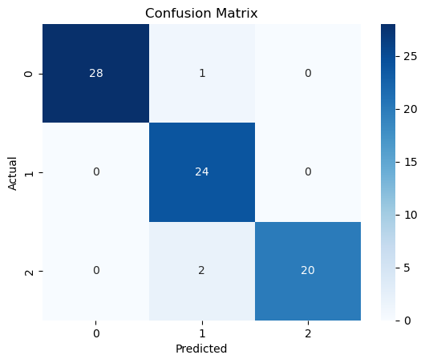

```python
confu_matrix = confusion_matrix(y_test, y_pred)

sns.heatmap(confu_matrix, annot=True, cmap="Blues")

plt.title("Confusion Matrix")

plt.xlabel("Predicted")

plt.ylabel("Actual")

plt.show()
```

### Confusion matrix Explanation

The confusion matrix shows a strong concentration of values along the diagonal, suggesting that the model performs well in identifying the correct species of flower.

## ROC Curve Analysis

The Receiver Operating Characteristic (ROC) curve illustrates the performance of a classification model at different classification thresholds.

The ROC curve plots the True Positive Rate against the False Positive Rate. A model with better predictive performance will produce a curve that approaches the upper-left corner of the graph.

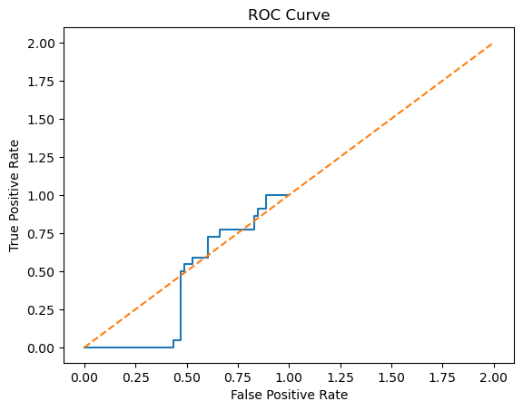

```python
y_prob = log_model.predict_proba(X_test)

fpr, tpr, _ = roc_curve(y_test, y_prob[:,1], pos_label=2)

plt.plot(fpr, tpr)

plt.plot([0,2],[0,2],'--')

plt.title("ROC Curve")

plt.xlabel("False Positive Rate")

plt.ylabel("True Positive Rate")

plt.show()
```

## Model Comparison

To evaluate whether logistic regression provides the best performance, additional classification models are trained and compared. In this analysis, Random Forest and Support Vector Machine (SVM) classifiers are implemented.

Comparing multiple models allows us to determine which algorithm produces the most accurate predictions for the dataset.

```python
# Define and train Random Forest model
Rf_model = RandomForestClassifier()
Rf_model.fit(X_train, y_train)
Rf_pred = Rf_model.predict(X_test)
Rf_accuracy = accuracy_score(y_test, Rf_pred)

# Define and train SVM model
SVM_model = SVC()
SVM_model.fit(X_train, y_train)
SVM_pred = SVM_model.predict(X_test)  # Fixed: SVM_model instead of svm_model
SVM_accuracy = accuracy_score(y_test, SVM_pred)

# Print results
print("Logistic Regression:", accuracy)  # Note: 'accuracy' variable is not defined in this snippet
print("Random Forest:", Rf_accuracy)  # Fixed: Rf_accuracy instead of RF_accuracy
print("SVM:", SVM_accuracy)  # Fixed: SVM_accuracy instead of svm_accuracy
```

```
Logistic Regression: 0.96
Random Forest: 0.9466666666666667
SVM: 0.9733333333333334
```

### Model Comparison Explanation

To determine the most effective classification algorithm for predicting iris flower species, three machine learning models were compared: Logistic Regression, Support Vector Machine (SVM), and Random Forest. The comparison was based on their accuracy scores obtained from the testing dataset.

The Logistic Regression model achieved an accuracy of 0.96, meaning that it correctly classified 96% of the observations. This indicates that logistic regression performs very well in capturing the relationship between the flower measurements and their corresponding species.

The Support Vector Machine (SVM) model produced the highest accuracy score of 0.97, correctly classifying 97% of the test observations. This suggests that SVM was slightly more effective at separating the different species classes within the dataset, making it the best-performing model among the three algorithms tested.

The Random Forest model achieved an accuracy score of 0.95, correctly predicting 95% of the observations. While this performance is still strong, it was slightly lower than both logistic regression and SVM in this particular dataset.

The comparison shows that all three models performed well in classifying iris species, with accuracy levels above 90%. However, the SVM model demonstrated the best predictive performance, followed closely by Logistic Regression, while Random Forest performed slightly lower.

## Conclusion

This task demonstrated the application of machine learning classification techniques using the Iris dataset. Logistic regression was successfully implemented the model showed a predictive value of 0.96, which is highly significant to predict iris species based on flower measurements.

The results highlight the effectiveness of machine learning algorithms in solving classification problems and demonstrate the importance of proper preprocessing, feature scaling, and model evaluation in building reliable predictive models.

```python
!jupyter nbconvert --to html "codveda_level2_data_cleaning_and_preprocessing_task2.ipynb"
```